# Discharge Data Example

Matthew Ross | assignment completed by George Woolsey

25 January, 2022

# Methods

The Poudre River at Lincoln Bridge is:

- Downstream of only a little bit of urban stormwater
- Near Odell Brewing CO
- Near an open space area and the Poudre River Trail
- **Downstream of many agricultral diversions**

## Site Description

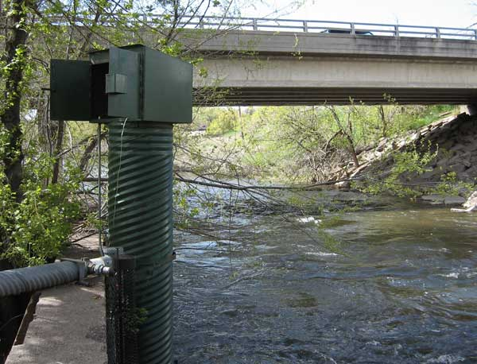

## Data Acquisition and Plotting tests

## Data Download

```r
q <- readNWISdv(siteNumbers = '06752260',
                parameterCd = '00060',
                startDate = '2017-01-01',
                endDate = '2022-01-01') %>%
  rename(q = 'X_00060_00003')
```

## Static Data Plotter

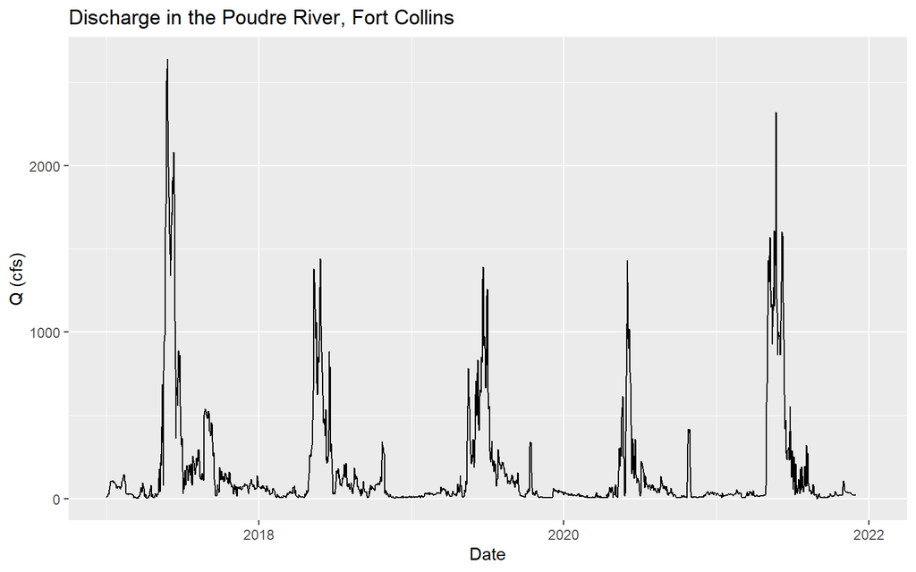

```r
ggplot(q, aes(x = Date, y = q)) +
  geom_line() +
  ylab('Q (cfs)') +
  ggtitle('Discharge in the Poudre River, Fort Collins')
```

## Interactive Data Plotter

```r
q_xts <- xts(q$q, order.by = q$Date)


dygraph(q_xts, main = "Discharge in the Poudre River, Fort Collins, CO") %>%
  dyAxis("y", label = "Discharge (cfs)")
```

[interactive chart not shown]

# Assignment

This assignment will be primarily about demonstrating some expertise in using RMarkdown, since we will be using Rmds as the primary form of homework and assignments. With that in mind, your assignment for this homework is to:

1. Fork the example repository into your personal GitHub
2. Create an RStudio project from your Personal clone of the Repo.
3. Create a table of contents that is floating, but displays three levels of headers instead of two (by editing the content at the beginning of the document)
4. Make a version of the `dygraph` with points and lines by using rstudio’s dygraph [guide](https://rstudio.github.io/dygraphs/)
5. Writing a paragraph on the Poudre river with at least three hyperlinks, **two bolded sections**, and one *italicized phrase*. The content of this paragraph is not vital, but try to at least make it true and interesting, and, of course, don’t plagiarize.
6. Knit that document, and then git commit and push to your personal GitHub.
7. Use the GitHub -> Settings -> Pages tab to create a website of your report.
8. Bonus, make the timestamp in the header dynamic. As in it only adds todays date, not just a static date you enter.
9. Bonus, create an “index_talk.Rmd” version of your document using the `revealjs` package. Add link to your original report-style document.

## DyGraph example

### Interact with this chart!

```r
q_xts <- xts(q$q, order.by = q$Date)


dygraph(q_xts, main = "Discharge in the Poudre River, Fort Collins, CO") %>%
  dyAxis("y", label = "Discharge (cfs)") %>%
  dyOptions(drawPoints = TRUE, pointSize = 2)
```

[interactive chart not shown]

## Poudre Paragraph

The Cache la Poudre River in Larimer County, Colorado is *one of 55 designated [National Heritage Areas](https://www.nps.gov/places/cache-la-poudre-river-national-heritage-area.htm)* in the United States. The river showcases historical developments built by early Euro-American settlers, a popular trail system which follows the river through Fort Collins, and miles of natural beauty which, despite increasing human development, remains prime wildlife habitat. The **Bird Conservancy of the Rockies** has organized a community science project to study Eastern Screech-Owls along the Cache la Poudre River in Fort Collins and is currently [seeking volunteer surveyors](https://www.birdconservancy.org/get-involved/volunteer/citizen-science/) for the period March to mid-May. For those interested in the water flow dynamics of the river, there are several stream gauges maintained by **Colorado Division of Water Resources** with open access to data.

### Map of Poudre River Trail System

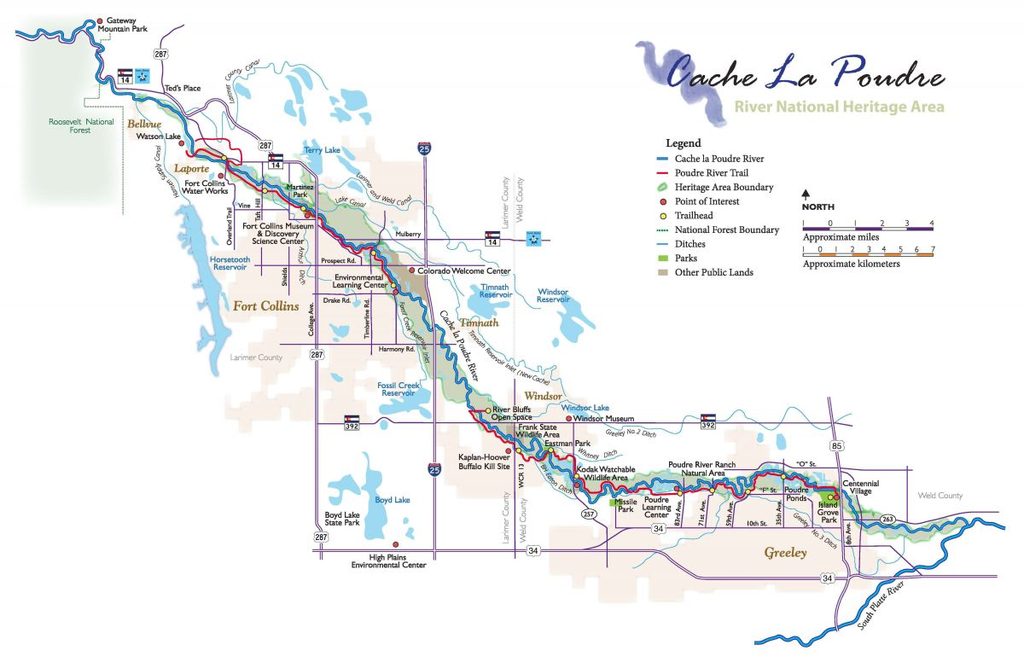

## Link to presentation-style webpage

[Go to presentation](https://georgewoolsey.github.io/1_rmarkdown_examples/index_talk#/)